# Lab 4

Author

Erin Yu

# Lab 4

#Read in the Data

```r
if (!file.exists("met_all.gz")) {
  download.file(
    url = "https://raw.githubusercontent.com/USCbiostats/data-science-data/master/02_met/met_all.gz",
    destfile = "met_all.gz",
    method   = "libcurl",
    timeout  = 60
  )
}
met <- data.table::fread("met_all.gz")

library(data.table)
library(ggplot2)
```

#Prepare the Data

```r
#Remove temperatures less than -17C
met <- met[met$temp > -17] [elev == 9999.0, elev := NA]

#Generate a date variable
met[, date := as.Date(paste(year, month, day, sep = "-"))]

met <- met[as.integer(format(date, "%d")) <= 7]

#Compute means by station
met_avg <- met[,.(
  mean_temp = mean(temp,na.rm = TRUE),
  mean_rh = mean(rh,na.rm = TRUE),
  mean_wind_sp = mean(wind.sp,na.rm = TRUE),
  mean_vis_dist = mean(vis.dist,na.rm = TRUE),
  mean_dew_point = mean(dew.point,na.rm = TRUE),
  lat = mean(lat,na.rm = TRUE),
  lon = mean(lon,na.rm = TRUE),
  elev = mean(elev,na.rm = TRUE)
), by = USAFID]

#Create Region Variables
met_avg[, region := ifelse(lon < -98 & lat > 39.71, 'NW',
                    ifelse(lon < -98 & lat <= 39.71, 'SW',
                    ifelse(lon >= -98 & lat > 39.71, 'NE',
                            'SE')))]

#Create Categorical variables
met_avg[, elev_cat := ifelse(elev > 252, "high", "low")]
```

#Use geom_violin

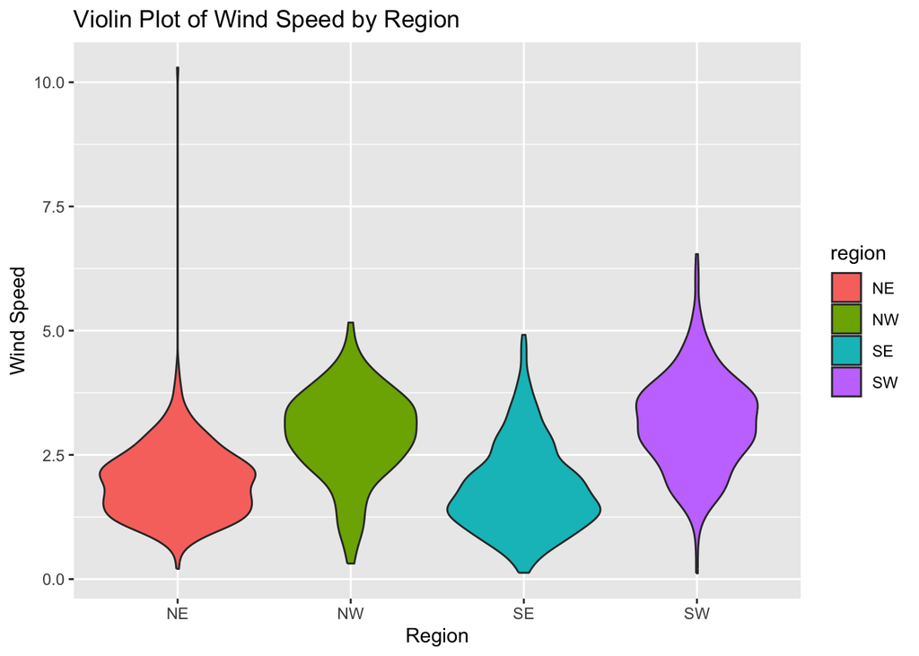

```r
library(ggplot2)

met_avg[!is.na(region) & !is.na(mean_wind_sp) & !is.na(mean_dew_point)] |>
  ggplot(aes(x = region, y = mean_wind_sp, fill = region))+
  geom_violin() +
  labs(title = "Violin Plot of Wind Speed by Region") +
  labs(x = "Region", y = "Wind Speed")
```

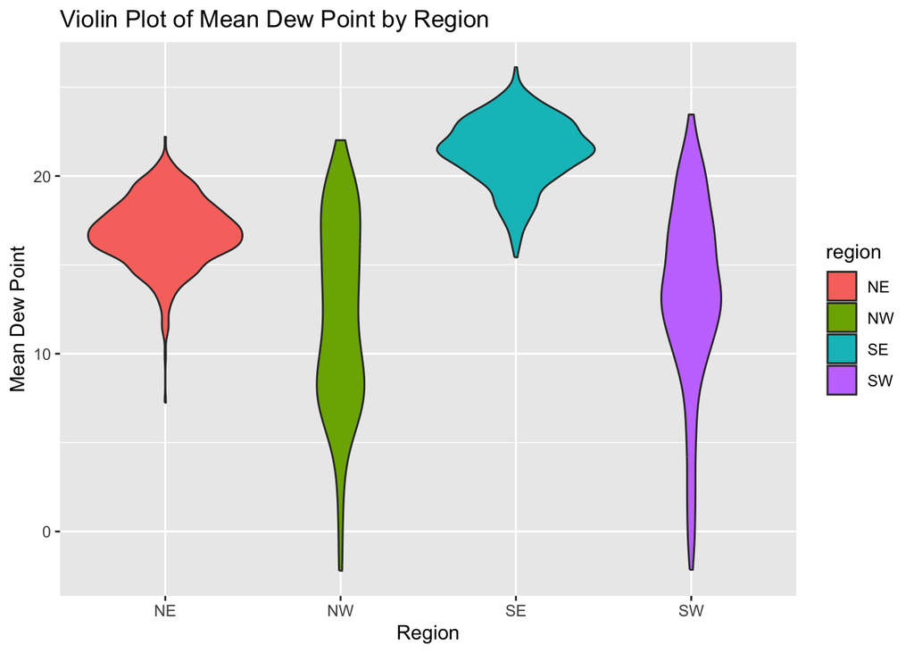

```r
met_avg[!is.na(region) & !is.na(mean_wind_sp) & !is.na(mean_dew_point)] |>
  ggplot(aes(x = region, y = mean_dew_point, fill = region))+
  geom_violin() +
  labs(title = "Violin Plot of Mean Dew Point by Region") +
  labs(x = "Region", y = "Mean Dew Point")
```

The average wind speed was lowest in the east, and highest in the west. The dew point was lower in the west than the east

#Use geom_jitter with stat_smooth

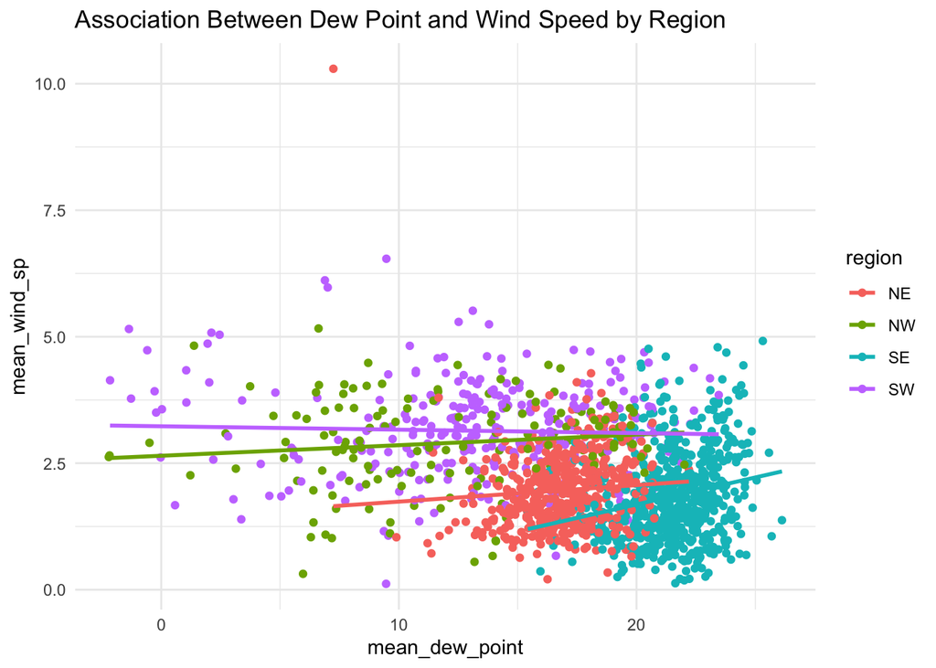

```r
library(ggplot2)

ggplot(met_avg, aes(x = mean_dew_point, y = mean_wind_sp, color = region)) +
  geom_jitter() +
  stat_smooth(method = "lm", se = FALSE) +
  labs(title = "Association Between Dew Point and Wind Speed by Region") +
  theme_minimal()
```

#Bar plot of weather stations

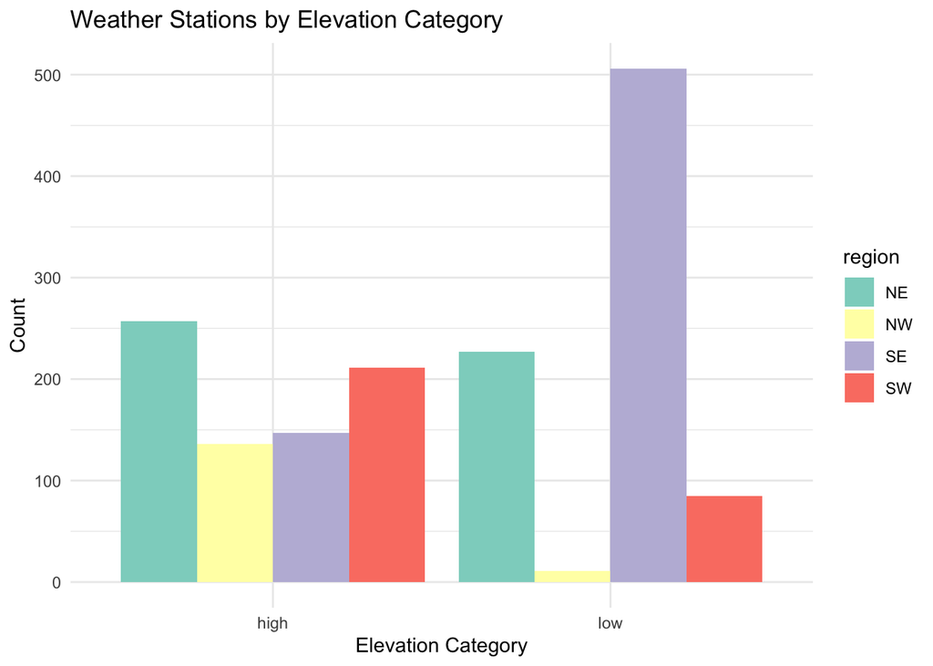

```r
library(ggplot2)
ggplot(met_avg, aes(x = elev_cat, fill = region)) +
  geom_bar(position = "dodge") +
  scale_fill_brewer(palette = "Set3") +
  labs(title = "Weather Stations by Elevation Category", x = "Elevation Category", y = "Count") +
  theme_minimal()
```

There seems to be the most weather stations in the SE in the low elevation. In the high elevation there are the most weather stations in the NE.

#Statistical Summary

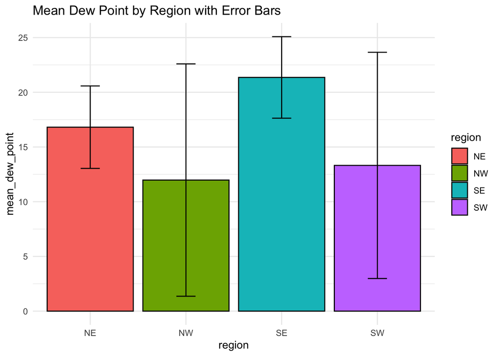

```r
library(Hmisc)
ggplot(met_avg, aes(x = region, y = mean_dew_point, fill = region)) +
  stat_summary(fun.data = "mean_sdl", geom = "bar", color = "black") +
  stat_summary(fun.data = "mean_sdl", geom = "errorbar", width = 0.2) +
  labs(title = "Mean Dew Point by Region with Error Bars") +
  theme_minimal()
```

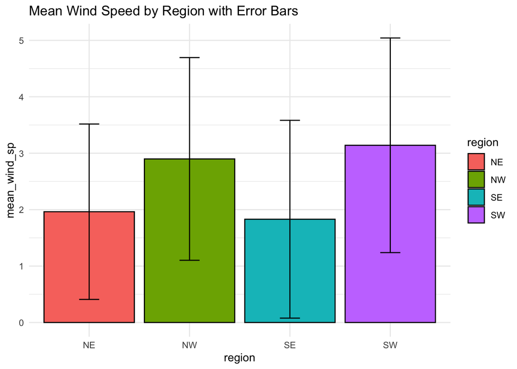

```r
ggplot(met_avg, aes(x = region, y = mean_wind_sp, fill = region)) +
  stat_summary(fun.data = "mean_sdl", geom = "bar", color = "black") +
  stat_summary(fun.data = "mean_sdl", geom = "errorbar", width = 0.2) +
  labs(title = "Mean Wind Speed by Region with Error Bars") +
  theme_minimal()
```

The mean wind speed was greater in the west than the east. The mean dew points were higher in the east than the west. There was large variation in the mean dew point in the west than the east. The variability of mean wind speed was equal across both west and east.

#Map showing spatial trend

```r
library(leaflet)
pal <- colorNumeric(palette = "Blues", domain = met_avg$mean_rh)

leaflet(met_avg) %>%
  addTiles() %>%
  addCircles(lng = ~lon, lat = ~lat, color = ~pal(mean_rh), radius = 50000) %>%
  addLegend("bottomright", pal = pal, values = ~mean_rh, title = "Relative Humidity") %>%
  addMarkers(lng = ~lon[rank(-mean_rh) <= 10], lat = ~lat[rank(-mean_rh) <= 10],
             popup = ~paste("RH: ", round(mean_rh, 2)))
```

[interactive chart not shown]

The relative humidities seem to be highest on the coasts, with an outlier in the middle north

#Use ggplot extension

```r
library(ggplot2)
library(gganimate)
animate_data <- met_avg[is.finite(met_avg$mean_rh) & is.finite(met_avg$mean_wind_sp), ]


  ggplot(animate_data)+
  geom_boxplot(mapping=aes(x = region, y = mean_wind_sp, fill = region))+
  labs(title = "Wind Speed and Dew Point by Region")+
  labs(x = "Dew Point", y = "Wind Speed")+
  transition_states(
    region,
    transition_length = 4,
    state_length = 2
  )+
  enter_fade()+
  exit_shrink()+
  ease_aes('sine-in-out')
```

[output not shown]